# CUNY 621 Final Project Literature Search

Joel Park

5/1/2018

# Mental Health Literature Research

The Substance Abuse and Mental Health Services Administration had conducted a survey that focused on **any mental illness (AMI)** and **serious mental illness (SMI)**. According to the administration, AMI is “defined as a mental, behavioral, or emotional disorder. AMI can vary in impact, ranging from no impariment to mild, moderate, and even severe impairment (e.g., individuals with serious mental illness).” A SMI is “defined as a mental, behavioral, or emotional disorder resulting in serious functional impairment, which substantially interferes with or limits one or more major life activities. The burden of mental illnesses is particularly concentrated among those who experience disability due to SMI.”$^1$

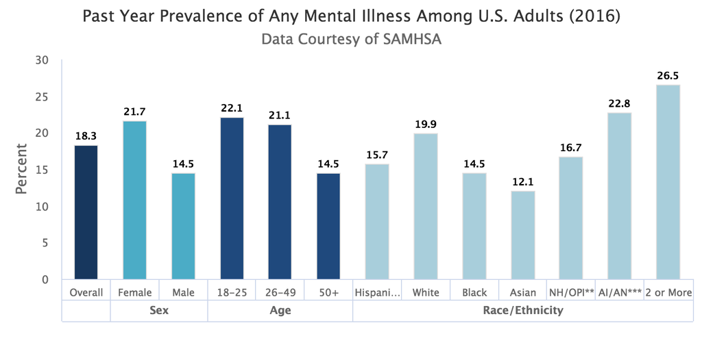

This data from the 2016 survey displays the prevalence rates of mental illneses among US adults. Not surprisingly, all races, genders, and age were affected by mental illness. (Please note that our paper was utilizing data that was collected from the 2014 survey.) This begets a discussion on the morbidity and mortality that is associated with mental illness, specifically suicide. “Suicide …is a major cause of death throughout the world and a leading cause of death among the young. Aproximately 2 percent of the general population have seriously considered taking their lives and only approximately 1 percent have actually attempted suicide. Suicide thinking is more requent among women than among men and is associated with a clinical depression, social isolation, and undesirable life events.” Substance abuse is another unfortunate consequence. Many patients with mental health illnesses often attempt to cope with their struggles by using potentially hazardous and illicit pharmacological agents such as alcohol, narcotics, and benzodiazepines. Abuse of such agents can lead to long term medical health complications thus creating a vicious cycle of mental and physical health issues.$^2$

Depression is one of the most common mental health illnesses in the United States. The factors that tend to aggravate mental health are the usual suspects, such as isolation, poor social support, prolonged duration and high intensity levels of stress, trauma, and among many other factors.$^3$ And not suprisingly, high-stress fields such as the technology sector may tend to worsen mental health.$^4$ Many may feel pressured to not seek care or report their mental illnesses, as they may be afraid of being stigmatized, and as a result, mental illness in this field may likely be underreported and underrepresented. Despite a thorough search through Google Scholar and Pubmed, literature is sparse regarding mental health prevalence rates within the technology sector. One source, the “Open Sourcing Mental Illness”$^5$ have conducted surveys and attempted to elucidate this information. Taking this information, the authors have hoped to obtain preliminary information and to create more research in this ill-defined field. By performing rigorous data analysis and regression, we, as data scientists, hope to clarify any underlying patterns that exist in mental health illnesses within the technology industry.

Reference:

âMental Illness.â National Institute of Mental Health, U.S. Department of Health and Human Services, Nov. 2017, www.nimh.nih.gov/health/statistics/mental-illness.shtml.

âPsychosocial Disorders.â Emergency Medicine Manual, Sixth Edition, by O. John. Ma and David Cline, McGraw-Hill, Medical Pub. Division, 2004, pp. 1807â“1816.

Harvard Health Publishing. âWhat Causes Depression? - Harvard Health.â Harvard Health Blog, 17 Apr. 2017, www.health.harvard.edu/mind-and-mood/what-causes-depression.

Evans, Judith, et al. âMental Illness Flourishes in High-Pressure Workplace.â Financial Times, Financial Times, 14 Sept. 2016, www.ft.com/content/d4168a70-4533-11e6-9b66-0712b3873ae1.

âOSMI Home.â Open Sourcing Mental Illness - Changing How We Talk about Mental Health in the Tech Community - Stronger Than Fear, osmihelp.org/.